# R Notebook

### Load Data

```r
library(readr)
set.seed(100)
df= read_csv("https://archive.ics.uci.edu/ml/machine-learning-databases/abalone/abalone.data",
             col_names =F)
names(df)=c('Sex','Length','Diameter','Height','Whole_weight','Shucked_weight',
            'Viscera_weight','Shell_weight','Rings')
head(df)
```

| Sex | Length | Diameter | Height | Whole_weight | Shucked_weight | Viscera_weight | Shell_weight | Rings |
| --- | --- | --- | --- | --- | --- | --- | --- | --- |
| M | 0.455 | 0.365 | 0.095 | 0.5140 | 0.2245 | 0.1010 | 0.150 | 15 |
| M | 0.350 | 0.265 | 0.090 | 0.2255 | 0.0995 | 0.0485 | 0.070 | 7 |
| F | 0.530 | 0.420 | 0.135 | 0.6770 | 0.2565 | 0.1415 | 0.210 | 9 |
| M | 0.440 | 0.365 | 0.125 | 0.5160 | 0.2155 | 0.1140 | 0.155 | 10 |
| I | 0.330 | 0.255 | 0.080 | 0.2050 | 0.0895 | 0.0395 | 0.055 | 7 |
| I | 0.425 | 0.300 | 0.095 | 0.3515 | 0.1410 | 0.0775 | 0.120 | 8 |

```r
str(df)
```

```
tibble [4,177 x 9] (S3: spec_tbl_df/tbl_df/tbl/data.frame)
 $ Sex           : chr [1:4177] "M" "M" "F" "M" ...
 $ Length        : num [1:4177] 0.455 0.35 0.53 0.44 0.33 0.425 0.53 0.545 0.475 0.55 ...
 $ Diameter      : num [1:4177] 0.365 0.265 0.42 0.365 0.255 0.3 0.415 0.425 0.37 0.44 ...
 $ Height        : num [1:4177] 0.095 0.09 0.135 0.125 0.08 0.095 0.15 0.125 0.125 0.15 ...
 $ Whole_weight  : num [1:4177] 0.514 0.226 0.677 0.516 0.205 ...
 $ Shucked_weight: num [1:4177] 0.2245 0.0995 0.2565 0.2155 0.0895 ...
 $ Viscera_weight: num [1:4177] 0.101 0.0485 0.1415 0.114 0.0395 ...
 $ Shell_weight  : num [1:4177] 0.15 0.07 0.21 0.155 0.055 0.12 0.33 0.26 0.165 0.32 ...
 $ Rings         : num [1:4177] 15 7 9 10 7 8 20 16 9 19 ...
 - attr(*, "spec")=
  .. cols(
  ..   X1 = col_character(),
  ..   X2 = col_double(),
  ..   X3 = col_double(),
  ..   X4 = col_double(),
  ..   X5 = col_double(),
  ..   X6 = col_double(),
  ..   X7 = col_double(),
  ..   X8 = col_double(),
  ..   X9 = col_double()
  .. )
```

```r
summary(df)
```

```
     Sex                Length         Diameter          Height        Whole_weight
 Length:4177        Min.   :0.075   Min.   :0.0550   Min.   :0.0000   Min.   :0.0020
 Class :character   1st Qu.:0.450   1st Qu.:0.3500   1st Qu.:0.1150   1st Qu.:0.4415
 Mode  :character   Median :0.545   Median :0.4250   Median :0.1400   Median :0.7995
                    Mean   :0.524   Mean   :0.4079   Mean   :0.1395   Mean   :0.8287
                    3rd Qu.:0.615   3rd Qu.:0.4800   3rd Qu.:0.1650   3rd Qu.:1.1530
                    Max.   :0.815   Max.   :0.6500   Max.   :1.1300   Max.   :2.8255
 Shucked_weight   Viscera_weight    Shell_weight        Rings
 Min.   :0.0010   Min.   :0.0005   Min.   :0.0015   Min.   : 1.000
 1st Qu.:0.1860   1st Qu.:0.0935   1st Qu.:0.1300   1st Qu.: 8.000
 Median :0.3360   Median :0.1710   Median :0.2340   Median : 9.000
 Mean   :0.3594   Mean   :0.1806   Mean   :0.2388   Mean   : 9.934
 3rd Qu.:0.5020   3rd Qu.:0.2530   3rd Qu.:0.3290   3rd Qu.:11.000
 Max.   :1.4880   Max.   :0.7600   Max.   :1.0050   Max.   :29.000
```

### Preprocess

```r
if(sum(sapply(df,is.factor))>0){
  factorCols= Filter(is.factor, df)
  factor_df= data.frame( sapply ( factorCols ,as.character),stringsAsFactors = F)
  df[names(factor_df)]=factor_df
}
str(df)
```

```
tibble [4,177 x 9] (S3: spec_tbl_df/tbl_df/tbl/data.frame)
 $ Sex           : chr [1:4177] "M" "M" "F" "M" ...
 $ Length        : num [1:4177] 0.455 0.35 0.53 0.44 0.33 0.425 0.53 0.545 0.475 0.55 ...
 $ Diameter      : num [1:4177] 0.365 0.265 0.42 0.365 0.255 0.3 0.415 0.425 0.37 0.44 ...
 $ Height        : num [1:4177] 0.095 0.09 0.135 0.125 0.08 0.095 0.15 0.125 0.125 0.15 ...
 $ Whole_weight  : num [1:4177] 0.514 0.226 0.677 0.516 0.205 ...
 $ Shucked_weight: num [1:4177] 0.2245 0.0995 0.2565 0.2155 0.0895 ...
 $ Viscera_weight: num [1:4177] 0.101 0.0485 0.1415 0.114 0.0395 ...
 $ Shell_weight  : num [1:4177] 0.15 0.07 0.21 0.155 0.055 0.12 0.33 0.26 0.165 0.32 ...
 $ Rings         : num [1:4177] 15 7 9 10 7 8 20 16 9 19 ...
 - attr(*, "spec")=
  .. cols(
  ..   X1 = col_character(),
  ..   X2 = col_double(),
  ..   X3 = col_double(),
  ..   X4 = col_double(),
  ..   X5 = col_double(),
  ..   X6 = col_double(),
  ..   X7 = col_double(),
  ..   X8 = col_double(),
  ..   X9 = col_double()
  .. )
```

### Explore Target Column

Rings is prediction column. It has 28 unique values. Its numeric so lets do try regression

```r
##
length(unique(df$Rings))
```

```
[1] 28
```

```r
nrow(df)
```

```
[1] 4177
```

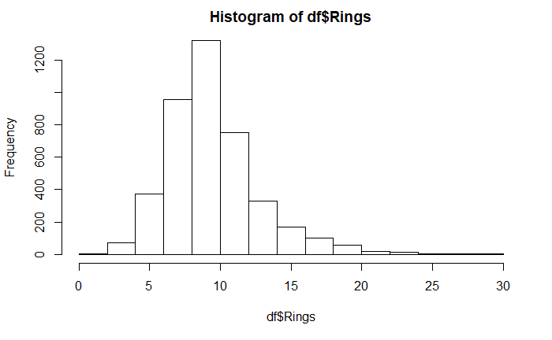

```r
hist(df$Rings)
```

### Train Test Split

Deepdive requires feature and target as seperate data.frames. Make sure to convert target as data.frame explicity with stringasfactor as false.

As best practise in deepdive set target column names as “y”.

```r
trainIndex= sample(1:nrow(df), 0.8 * nrow(df))
train_x = df[trainIndex ,!names(df)%in%'Rings']
train_y = df[trainIndex, names(df)%in%'Rings']

test_x = df[-trainIndex ,!names(df)%in%'Rings']
test_y = df[-trainIndex, names(df)%in%'Rings']
train_y= data.frame(train_y , stringsAsFactors = F)
test_y = data.frame(test_y , stringsAsFactors = F)
names(train_y)="y"
names(test_y)="y"
head(train_x)
```

| Sex | Length | Diameter | Height | Whole_weight | Shucked_weight | Viscera_weight | Shell_weight |
| --- | --- | --- | --- | --- | --- | --- | --- |
| M | 0.625 | 0.495 | 0.155 | 1.1770 | 0.5055 | 0.2780 | 0.3450 |
| F | 0.620 | 0.470 | 0.225 | 1.1150 | 0.3780 | 0.2145 | 0.3600 |
| I | 0.280 | 0.210 | 0.065 | 0.1110 | 0.0425 | 0.0285 | 0.0300 |
| F | 0.650 | 0.520 | 0.195 | 1.2810 | 0.5985 | 0.2460 | 0.3825 |
| M | 0.610 | 0.365 | 0.155 | 1.0765 | 0.4880 | 0.2490 | 0.2700 |
| M | 0.595 | 0.480 | 0.140 | 0.9125 | 0.4095 | 0.1825 | 0.2890 |

```r
head(train_y)
```

```
   y
1  9
2 15
3  6
4 10
5  9
6  9
```

```r
head(test_x)
```

| Sex | Length | Diameter | Height | Whole_weight | Shucked_weight | Viscera_weight | Shell_weight |
| --- | --- | --- | --- | --- | --- | --- | --- |
| F | 0.545 | 0.425 | 0.125 | 0.7680 | 0.2940 | 0.1495 | 0.260 |
| M | 0.430 | 0.350 | 0.110 | 0.4060 | 0.1675 | 0.0810 | 0.135 |
| F | 0.470 | 0.355 | 0.100 | 0.4755 | 0.1675 | 0.0805 | 0.185 |
| I | 0.380 | 0.275 | 0.100 | 0.2255 | 0.0800 | 0.0490 | 0.085 |
| F | 0.550 | 0.415 | 0.135 | 0.7635 | 0.3180 | 0.2100 | 0.200 |
| F | 0.580 | 0.450 | 0.185 | 0.9955 | 0.3945 | 0.2720 | 0.285 |

```r
head(test_y)
```

```
   y
1 16
2 10
3 10
4 10
5  9
6 11
```

#### Default Settings

Check console to view progess

```r
library(deepdive)
mod_c_deepnet = deepnet(
  train_x,
  train_y,
  modelType = c("regress") #Default is regress so change to multiClass
  )
```

```
iteration 99: 17.7583508666387
iteration 199: 17.6340185187165
iteration 299: 17.538345464863
iteration 399: 17.4574164382377
iteration 500: 17.3858710302616
```

With each iteration model prints error value.Lower the value get higher the train accuracy. This would be helpful in tuning the parameters.Lets at train test accuracy.

By default Deepnet would build ANN with 2 hidden layers and 2 units in each layer + an output layer. 1st layer uses sigmoid activation and second uses relu. Output layer is automatically configured based on model type. Adam optimisation is used in default.

One can easily build a deeper ANN. We will see this later

#### Lets review predictions

```r
trainPred=predict(mod_c_deepnet,train_x)
testPred = predict(mod_c_deepnet,test_x)
head(trainPred)
```

```
     ypred
2 26.96422
3 26.96472
4 26.96694
5 26.96383
6 26.96442
7 26.96479
```

### Lets Review the Accuracy

Disclaimer : Default model is not optimised for accuracy.So do not except good accuracy before tuning

```r
Rmse = sqrt(mean((train_y$y-trainPred$ypred)^2))
TestRmse = sqrt(mean((test_y$y-testPred$ypred)^2))
data.frame(TrainRmse=round(Rmse,2),
           'TrainError%'=paste(round(mean(Rmse)/mean(train_y$y) *100,2),"%"),
           TestRmse=round(TestRmse,2),
           'TestError%'=paste(round(mean(TestRmse)/mean(test_y$y) *100,2),"%"))
```

```
  TrainRmse TrainError. TestRmse TestError.
1     17.39    175.96 %    17.12   168.79 %
```

### Tuning

There is no hard & fast rule in tuning , so methods like gridsearch or random search can be employed. For understanding the parameters lets tune few parameters at a time

hiddenLayerUnits: No. elements in hiddenLayerUnits vector is no. of layers in ANN. So here model after multiple tries we choose two layers with 20 units and 10 units respectively. Output layer will be automatically created based on model type.

iteration : Check the console for model progress. If you see error continues to decrease you continue increasing iteration till train accuracy and test accuracy go down.

eta : this is learning rate. Model accuraccy might drastically change wih this change. Higher eta would mean faster convergence. Sometimes high eta might make error start increasing after certain iteration.

These will be prime paramters to change to improve accuracy.

```r
mod_c_deepnet = deepnet(
  train_x,
  train_y,
  hiddenLayerUnits = c(20,10),
  activation = c("sin", "sin"),
  iterations = 200,  # Error did not change much so we reduce iterations
  eta=50,
  modelType = c("regress") #Default is regress so change to multiClass
  )
```

```
iteration 39: 3.72458709663729
iteration 79: 2.51110037236281
iteration 119: 2.23897962957833
iteration 159: 2.17920360031931
iteration 200: 2.13755672617022
```

```r
trainPred=predict(mod_c_deepnet,train_x)
testPred = predict(mod_c_deepnet,test_x)
Rmse = sqrt(mean((train_y$y-trainPred$ypred)^2))
TestRmse = sqrt(mean((test_y$y-testPred$ypred)^2))
data.frame(TrainRmse=round(Rmse,2),
           'TrainError%'=paste(round(mean(Rmse)/mean(train_y$y) *100,2),"%"),
           TestRmse=round(TestRmse,2),
           'TestError%'=paste(round(mean(TestRmse)/mean(test_y$y) *100,2),"%"))
```

```
  TrainRmse TrainError. TestRmse TestError.
1      2.14     21.63 %      2.2    21.65 %
```

#### DeepTree :

This is a experimental ensemble in deepdive package.

This model will create a decision tree model and then fit neural network i.e deepnet on leaf on decision tree.

The iteration msg will show error progress in each leaf.

Parameters is almost simillar to deepnet and in addition tree parameter like minsplit can be changed.

```r
mod_c_deeptree <-deeptree(
  train_x,
  train_y,
  hiddenLayerUnits = c(20, 10,10),
  activation = c("sin", "sin",'sin'),
  modelType = "regress",
  iterations = 1000,
  eta = 2,
  treeMinSplitPercent = 0.8,
  treeMinSplitCount = 100,
  treeCp = 0.01,
  miniBatchSize=128
)
```

```
iteration 99: 2.9158551974719
iteration 199: 3.0615754796191
iteration 299: 2.81153648244649
iteration 399: 2.73817613705443
iteration 499: 3.12140556294659
iteration 599: 3.18606084977078
iteration 699: 2.77819605560597
iteration 799: 2.84459697874242
iteration 899: 2.6403473803687
iteration 1000: 2.99109485988372
iteration 99: 2.13916499125363
iteration 199: 1.88006913409146
iteration 299: 2.07378483876252
iteration 399: 2.14037296485346
iteration 499: 2.04631847879687
iteration 599: 2.02205683748404
iteration 699: 2.30516758437173
iteration 799: 2.01498425052299
iteration 899: 1.40377787038544
iteration 1000: 1.83991855692425
```

Deeptree has not improved the accuracy

```r
trainPred=predict(mod_c_deeptree,train_x)
testPred = predict(mod_c_deeptree,test_x)
Rmse = sqrt(mean((train_y$y-trainPred$ypred)^2))
TestRmse = sqrt(mean((test_y$y-testPred$ypred)^2))
data.frame(TrainRmse=round(Rmse,2),
           'TrainError%'=paste(round(mean(Rmse)/mean(train_y$y) *100,2),"%"),
           TestRmse=round(TestRmse,2),
           'TestError%'=paste(round(mean(TestRmse)/mean(test_y$y) *100,2),"%"))
```

```
  TrainRmse TrainError. TestRmse TestError.
1       3.8     38.41 %     3.73    36.75 %
```

# DeepForest Default

DeepForest is based on deepnet and deeptree. Multiple Deepnets or deeptrees are built based on supplied parameters. Random subsets of data and columns are chosen to build model.

treeAugment = TRUE is to build deeptree forest and FALSE for deepnet forest.

Usually on regression deepforest default settings might perfom well.

```r
mod_c_deepforest<-
deepforest(
  train_x,
  train_y,
  networkCount = 3,
  layerChoice = c(2:3),
  unitsChoice = c(4:10),
  cutVarSizePercent = 0.6,
  cutDataSizePercent = 0.6,
  activation = c("sigmoid", "sigmoid"),
  reluLeak = 0,
  modelType = "regress",
  iterations = 500,
  eta = 10^-2,
  seed = 2,
  gradientClip = 0.8,
  regularisePar = 0,
  optimiser = "adam",
  parMomentum = 0.9,
  inputSizeImpact = 1,
  parRmsPropZeroAdjust = 10^-8,
  parRmsProp = 0.9999,
  treeLeaves = NA,
  treeMinSplitPercent = 0.3,
  treeMinSplitCount = 100,
  treeCp = 0.01,
  errorCover = 0.2,
  treeAugment = TRUE,
  printItrSize = 100,
  showProgress = TRUE,
  stopError = 0.01,
  miniBatchSize = NA,
  useBatchProgress = TRUE
)
```

```
iteration 99: 3.42092780180721
iteration 199: 2.83672260674385
iteration 299: 2.58189046944183
iteration 399: 2.47439512152152
iteration 500: 2.43157787809913
iteration 99: 3.25268357082201
iteration 199: 2.94832614216487
iteration 299: 2.8453650437892
iteration 399: 2.81101516138414
iteration 500: 2.80021261178436
iteration 99: 2.42865035223057
iteration 199: 2.0458243410807
iteration 299: 1.91919750496313
iteration 399: 1.88051128419557
iteration 500: 1.86932516849567
iteration 99: 1.71275516001147
iteration 199: 1.70944535736567
iteration 299: 1.70766593416045
iteration 399: 1.70607458686948
iteration 500: 1.70443940520158
iteration 99: 3.99791683634765
iteration 199: 3.46740434062134
iteration 299: 3.33670881678276
iteration 399: 3.30811574699845
iteration 500: 3.30205823530483
iteration 99: 1.64027466516001
iteration 199: 1.63601889521552
iteration 299: 1.63430240442197
iteration 399: 1.63271580053431
iteration 500: 1.63126401371535
iteration 99: 3.59114430589792
iteration 199: 3.01397156983371
iteration 299: 2.71896835199031
iteration 399: 2.5651734699934
iteration 500: 2.48697409486055
iteration 99: 3.56750733787771
iteration 199: 3.56032105032523
iteration 299: 3.5595762806954
iteration 399: 3.55889223940338
iteration 500: 3.55824319271839
```

[output cut: 30 more lines]

```
iteration 99: 7.40268888301769
iteration 199: 5.52395175508321
iteration 299: 4.49390438400367
iteration 399: 3.93880663187617
iteration 500: 3.65719944738244
iteration 99: 11.5777145650565
iteration 199: 9.96546759039137
iteration 299: 8.7760300210678
iteration 399: 7.83176544992639
iteration 500: 7.0584545683145
iteration 99: 6.53122513159146
iteration 199: 5.73449226683466
iteration 299: 5.13865134347159
iteration 399: 4.65792310716094
iteration 500: 4.25705052962635
```

```r
trainPred=predict(mod_c_deepforest,train_x)
testPred = predict(mod_c_deepforest,test_x)
Rmse = sqrt(mean((train_y$y-trainPred$ypred)^2))
TestRmse = sqrt(mean((test_y$y-testPred$ypred)^2))
data.frame(TrainRmse=round(Rmse,2),
           'TrainError%'=paste(round(mean(Rmse)/mean(train_y$y) *100,2),"%"),
           TestRmse=round(TestRmse,2),
           'TestError%'=paste(round(mean(TestRmse)/mean(test_y$y) *100,2),"%"))
```

```
  TrainRmse TrainError. TestRmse TestError.
1      2.45     24.84 %     2.49    24.49 %
```

#DeepForest Tune

```r
mod_c_deepforest<-
deepforest(
  train_x,
  train_y,
  networkCount = 3, # This paramentet determines number of deeptree or deepnet to build
  layerChoice = c(2:3),
  unitsChoice = c(4:10),
  cutVarSizePercent = 0.8,
  cutDataSizePercent = 0.6,
  activation = c("sin"), # activation will randomly chosen from this. Currently we will choose only
  reluLeak = 0,
  modelType = "regress",
  iterations = 600,
  eta = 0.15, # increasing eta
  seed = 2,
  gradientClip = 0.8,
  regularisePar = 0,
  optimiser = "adam",
  parMomentum = 0.9,
  inputSizeImpact = 1,
  parRmsPropZeroAdjust = 10^-8,
  parRmsProp = 0.9999,
  treeLeaves = NA,
  treeMinSplitPercent = 0.3,
  treeMinSplitCount = 100,
  treeCp = 0.01,
  errorCover = 0.2,
  treeAugment = TRUE,
  printItrSize = 100,
  showProgress = TRUE,
  stopError = 0.01,
  miniBatchSize = NA,  # Sometimes if data is too huge setting minibatchsize will work faster. As best practise use this when data goes beyond 10000 rows. Some batch sizes to try
#  30,128,1024. Read about mini batch gradient descent for clarity
  useBatchProgress = TRUE
)
```

```
iteration 99: 2.24087168468143
iteration 199: 2.04366799665249
iteration 299: 1.96577852379169
iteration 399: 1.91966356273759
iteration 499: 1.89379038872268
iteration 600: 1.88088151947363
iteration 99: 2.61825977201973
iteration 199: 2.46994357148573
iteration 299: 2.43527139226307
iteration 399: 2.40804839687365
iteration 499: 2.38435338489403
iteration 600: 2.36095485715468
iteration 99: 1.62815134655864
iteration 199: 1.55168020190489
iteration 299: 1.52444773243548
iteration 399: 1.50387421666366
iteration 499: 1.48729255721123
iteration 600: 1.47488193657126
iteration 99: 1.20034396323415
iteration 199: 1.18095670191343
iteration 299: 1.15946967567849
iteration 399: 1.13813985767188
iteration 499: 1.13192466794634
iteration 600: 1.1261781441877
iteration 99: 2.84903400170544
iteration 199: 2.64498088302922
iteration 299: 2.59465365099756
iteration 399: 2.56023844273893
iteration 499: 2.5339567928403
iteration 600: 2.50898886028631
iteration 99: 1.33015160547633
iteration 199: 1.27998464291654
iteration 299: 1.27470339098375
iteration 399: 1.27306243211414
iteration 499: 1.27069394768564
iteration 600: 1.26619298542256
iteration 99: 2.29202461375625
iteration 199: 2.06667129894815
iteration 299: 2.00596475135523
iteration 399: 1.96263670536841
```

[output cut: 47 more lines]

```
iteration 399: 2.84164658330253
iteration 499: 2.66061642894321
iteration 600: 2.55145550340099
iteration 99: 2.7464026715798
iteration 199: 2.65099413437499
iteration 299: 2.62011129972636
iteration 399: 2.61061704217193
iteration 499: 2.60186927677317
iteration 600: 2.57676820248771
iteration 99: 1.95527652201532
iteration 199: 1.79825265342242
iteration 299: 1.7477950783146
iteration 399: 1.71210650308804
iteration 499: 1.69478452030415
iteration 600: 1.68349245797649
```

```r
trainPred=predict(mod_c_deepforest,train_x)
testPred = predict(mod_c_deepforest,test_x)
Rmse = sqrt(mean((train_y$y-trainPred$ypred)^2))
TestRmse = sqrt(mean((test_y$y-testPred$ypred)^2))
data.frame(TrainRmse=round(Rmse,2),
           'TrainError%'=paste(round(mean(Rmse)/mean(train_y$y) *100,2),"%"),
           TestRmse=round(TestRmse,2),
           'TestError%'=paste(round(mean(TestRmse)/mean(test_y$y) *100,2),"%"))
```

```
  TrainRmse TrainError. TestRmse TestError.
1      1.99     20.16 %     2.05    20.22 %
```